# Exploratory Data Analysis - Red & White Wines

# Background

The purpose of this project is to emulate the process of exploring a data set and eventually extract meaningful insights. For this particular exercise, a database of wines was explored. For each entry of wine, various properties such as acidity, density, alcoholic content and pH along with a subjective quality rating of 0 to 10 were provided. I set two main questions to be answered through this exploration:

1. What properties can be used to differentiate red and white wines?
2. Can the quality rating be estimated using a combination of properties?

Below is the source of the dataset being explored:

P. Cortez, A. Cerdeira, F. Almeida, T. Matos and J. Reis. Modeling wine preferences by data mining from physicochemical properties. In Decision Support Systems, Elsevier, 47(4):547-553. ISSN: 0167-9236.

### High Level Characteristics of Dataset

- Number of observations: 6,497
- Number of attributes: 13
  1. fixed.acidity -> most acids involved with wine where it is fixed or nonvolatile (does not evaporate readily) [g/dm^3]
  2. volatile.acidity -> the amount of acetic acid in wine, which at  
     high levels can lead to an unpleasant, vinegar taste [g/dm^3]
  3. citric.acid -> found in small quantities, citric acid can add ‘freshness’ and flavor to wines [g/dm^3]
  4. reisdual.sugar -> the amount of sugar remaining after fermentation stops, it’s rare to find wines with less than 1 gram/liter and wines with greater than 45 grams/liter are considered sweet [g/dm^3]
  5. chlorides -> the amount of salt in the wine [g/dm^3]
  6. free.sulfur.dioxide -> the free form of SO2 exists in equilibrium between molecular SO2 (as a dissolved gas) and bisulfite ion; it prevents microbial growth and oxidation of wine [mg/dm^3]
  7. total.sulfur.dioxide -> amount of free and bound forms of S02; in low concentrations, SO2 is mostly undetectable in wine, but at free SO2 concentrations over 50 ppm, SO2 becomes evident in the nose and taste of wine [mg/dm^3]
  8. density -> the density of wine is close to that of water depending on the percent of alcohol and sugar content [g/cm^3]
  9. pH -> describes how acidic or basic a wine is on a scale from 0 (very acidic) to 14 (very basic); most wines are between 3-4 on the pH scale
  10. sulphates -> a wine additive, which can contribute to sulfur dioxide gas (S02) levels and acts as an antimicrobial and antioxidant [g/dm^3]
  11. alcohol -> the percent alcohol content of the wine [% by volume]
  12. quality -> output variable (based on sensory data) [score between 0 and 10]
  13. color -> indicates color of the wine [red/white]
  14. quality.bucket -> segregate wines into three quality buckets: (0,5], (5,7], and (7,10]
  15. quality.category -> segragate wines into three categories: low (0.5], medium (5,7], and high (7,10]
- Structure of dataset:

```
## 'data.frame':    6497 obs. of  17 variables:
##  $ X                   : int  0 1 2 3 4 5 6 7 8 9 ...
##  $ fixed.acidity       : num  7.4 7.8 7.8 11.2 7.4 7.4 7.9 7.3 7.8 7.5 ...
##  $ volatile.acidity    : num  0.7 0.88 0.76 0.28 0.7 0.66 0.6 0.65 0.58 0.5 ...
##  $ citric.acid         : num  0 0 0.04 0.56 0 0 0.06 0 0.02 0.36 ...
##  $ residual.sugar      : num  1.9 2.6 2.3 1.9 1.9 1.8 1.6 1.2 2 6.1 ...
##  $ chlorides           : num  0.076 0.098 0.092 0.075 0.076 0.075 0.069 0.065 0.073 0.071 ...
##  $ free.sulfur.dioxide : num  11 25 15 17 11 13 15 15 9 17 ...
##  $ total.sulfur.dioxide: num  34 67 54 60 34 40 59 21 18 102 ...
##  $ density             : num  0.998 0.997 0.997 0.998 0.998 ...
##  $ pH                  : num  3.51 3.2 3.26 3.16 3.51 3.51 3.3 3.39 3.36 3.35 ...
##  $ sulphates           : num  0.56 0.68 0.65 0.58 0.56 0.56 0.46 0.47 0.57 0.8 ...
##  $ alcohol             : num  9.4 9.8 9.8 9.8 9.4 9.4 9.4 10 9.5 10.5 ...
##  $ quality             : int  5 5 5 6 5 5 5 7 7 5 ...
##  $ color               : chr  "red" "red" "red" "red" ...
##  $ quality.ordered     : Ord.factor w/ 7 levels "3"<"4"<"5"<"6"<..: 3 3 3 4 3 3 3 5 5 3 ...
##  $ quality.bucket      : Ord.factor w/ 3 levels "(0,5]"<"(5,7]"<..: 1 1 1 2 1 1 1 2 2 1 ...
##  $ quality.category    : chr  "low" "low" "low" "medium" ...
```

- Summary of dataset:

```
##
## -------------------------------------------------------------------
##       X         fixed.acidity    volatile.acidity    citric.acid
## -------------- ---------------- ------------------ ----------------
##   Min.  : 0     Min.  : 3.800     Min.  :0.0800     Min.  :0.0000
##
##  1st Qu.:1624   1st Qu.: 6.400    1st Qu.:0.2300    1st Qu.:0.2500
##
##  Median :3248   Median : 7.000    Median :0.2900    Median :0.3100
##
##   Mean :3248     Mean : 7.215      Mean :0.3397      Mean :0.3186
##
##  3rd Qu.:4872   3rd Qu.: 7.700    3rd Qu.:0.4000    3rd Qu.:0.3900
##
##  Max.  :6496    Max.  :15.900     Max.  :1.5800     Max.  :1.6600
##
##       NA              NA                NA                NA
## -------------------------------------------------------------------
##
## Table: Table continues below
##
##
## -------------------------------------------------------------------------------
##  residual.sugar      chlorides      free.sulfur.dioxide   total.sulfur.dioxide
## ---------------- ----------------- --------------------- ----------------------
##  Min.  : 0.600    Min.  :0.00900       Min.  : 1.00           Min.  : 6.0
##
##  1st Qu.: 1.800   1st Qu.:0.03800     1st Qu.: 17.00         1st Qu.: 77.0
##
##  Median : 3.000   Median :0.04700     Median : 29.00         Median :118.0
##
##   Mean : 5.443     Mean :0.05603       Mean : 30.53           Mean :115.7
##
##  3rd Qu.: 8.100   3rd Qu.:0.06500     3rd Qu.: 41.00         3rd Qu.:156.0
##
##  Max.  :65.800    Max.  :0.61100       Max.  :289.00          Max.  :440.0
##
##        NA               NA                  NA                     NA
## -------------------------------------------------------------------------------
##
```

[output cut: 47 more lines]

```
## ------------------
##    Length:6497
##
##  Class :character
##
##  Mode :character
##
##         NA
##
##         NA
##
##         NA
##
##         NA
## ------------------
```

# Univariate Plots Section

Below are univariate plots for each wine property:

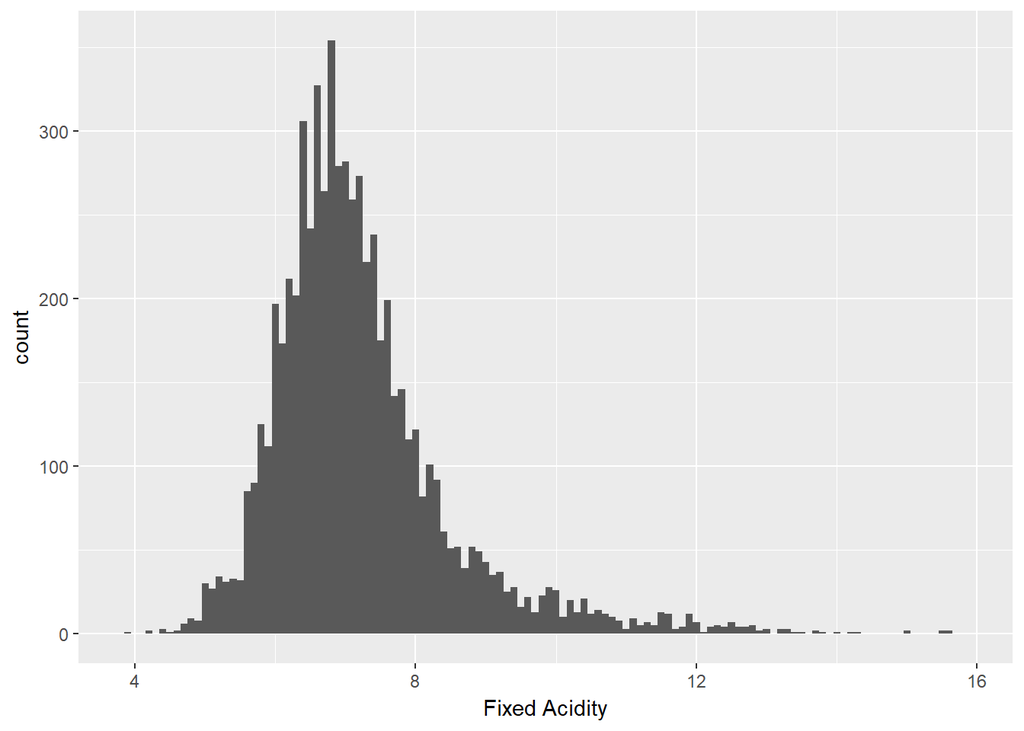

There is a high concentration of wines with fixed acidity around the median of 7 g/dm^3 but there are some outliers that increases the mean to 7.2g/dm^3.

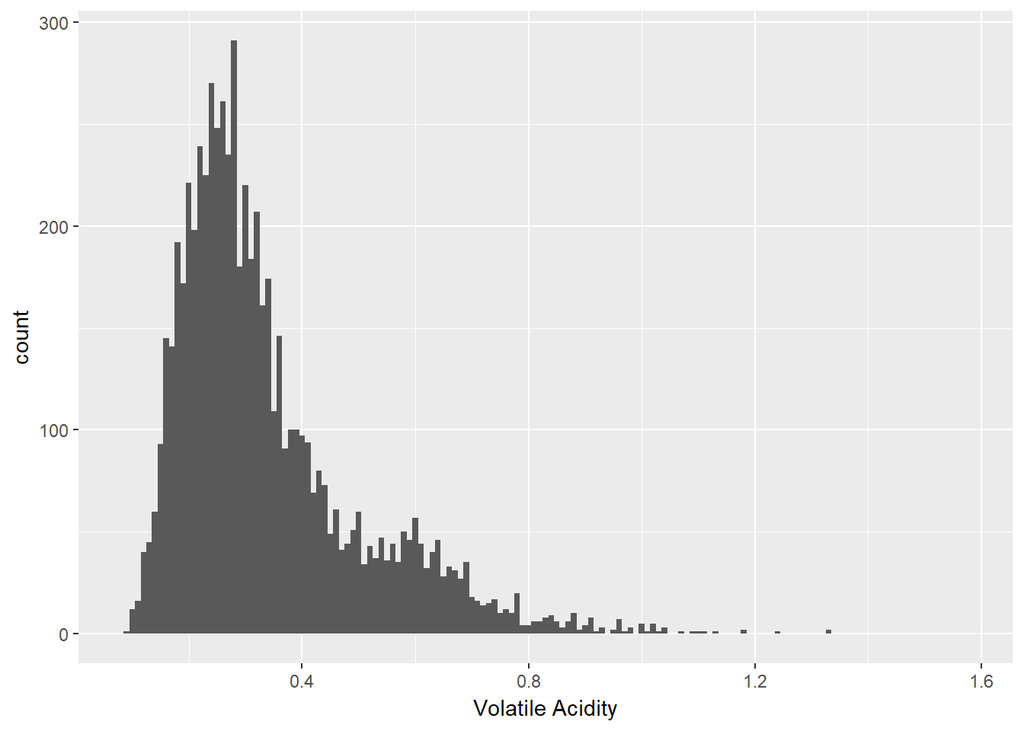

There appears to be some bimodalism with volatile acid, with a strong peak at 0.25g/dm^3 and another weaker peak at 0.58g/dm^3. Also there are a few outliers that deviate quite significantly from the median and mean that reach a maximum of 1.58 g/dm^3. At such high levels, one would assume that the wine would have a strong vinegar taste. Is this an indication that the wine has gone bad?

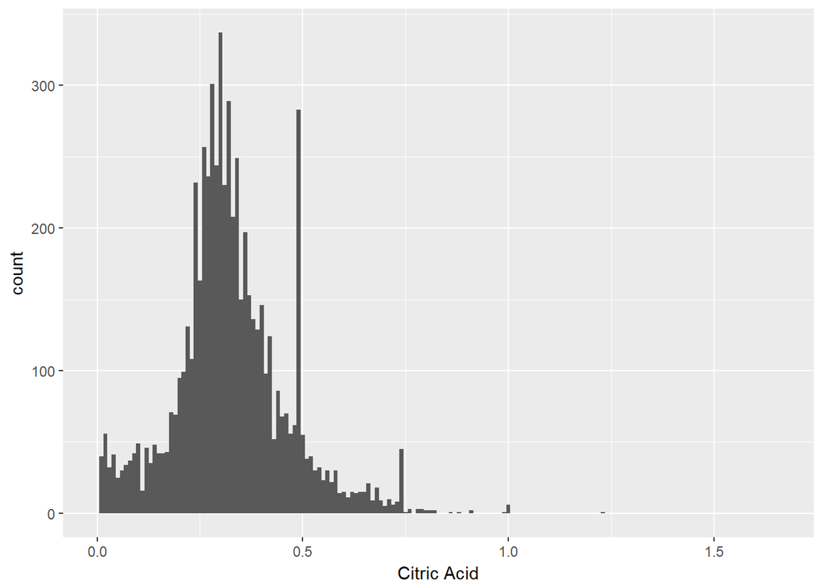

In general, citric acid demonstrates a normal distribution, whereby median and mean are almost equal at 0.31g/dm^3 and 0.32g/dm^3, respectively. There is strange spike at 0.5g/dm^3.

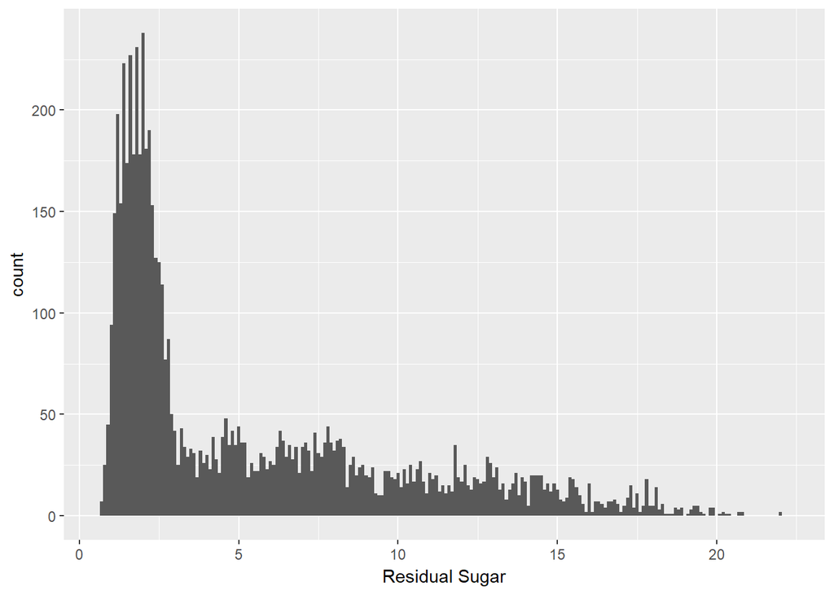

The plot for residual sugar is right skewed where there are a significant number of outliers with higher sugar content. Most wines, however, are concentrated around 3g/dm^3 (median).The plot above shows that the variability in sugar content in wines is quite wide.

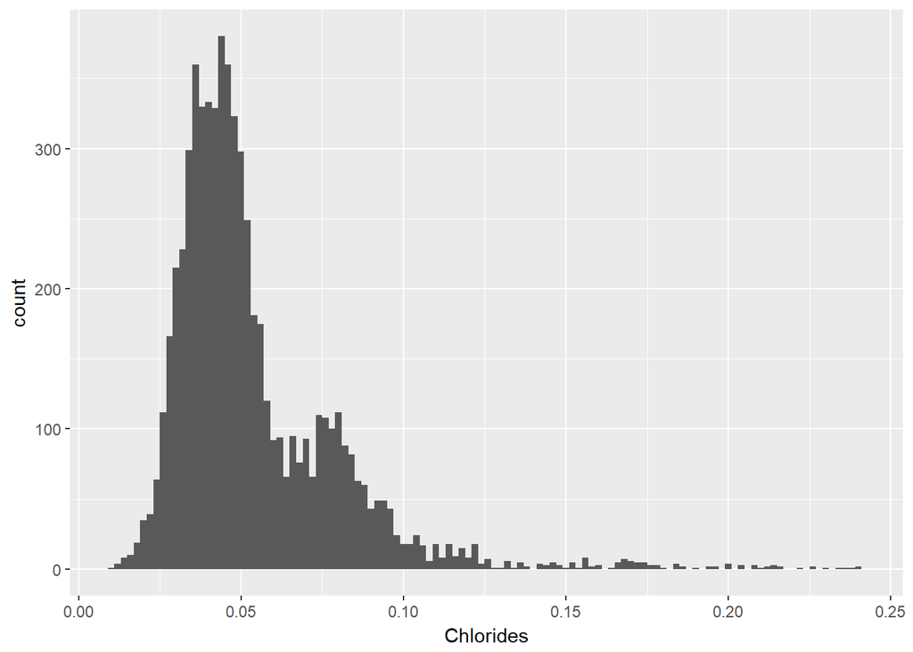

There appears to be some bimodalism with chlorides, with a strong peak at 0.04g/dm^3 and another weaker peak at 0.075g/dm^3.

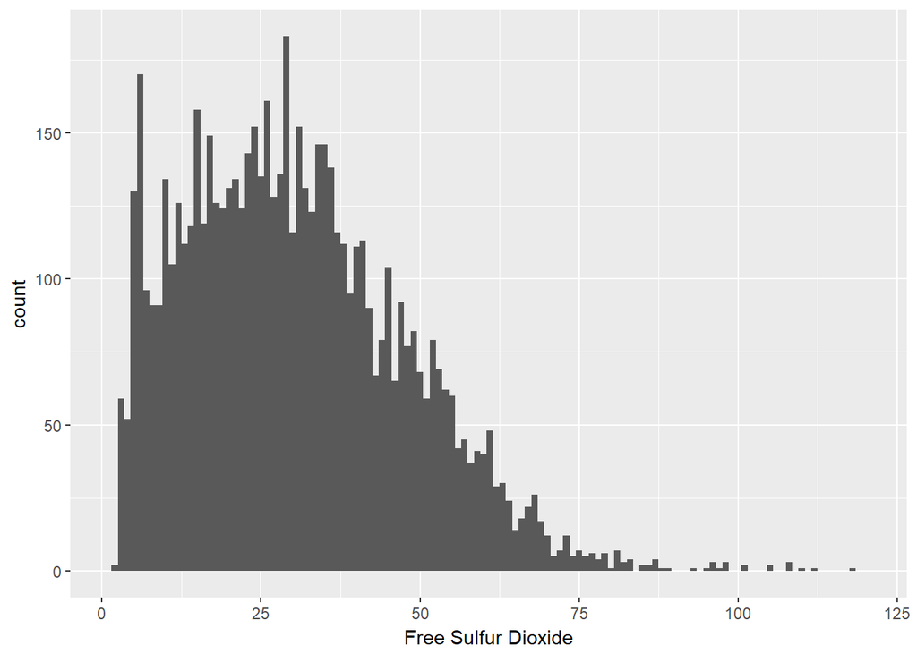

The plot for free sulfur dioxide is right skewed where there are a significant number of outliers with higher concentrations of free sulfur dioxide. Most wines, however, are concentrated around 29mg/dm^3 (median).

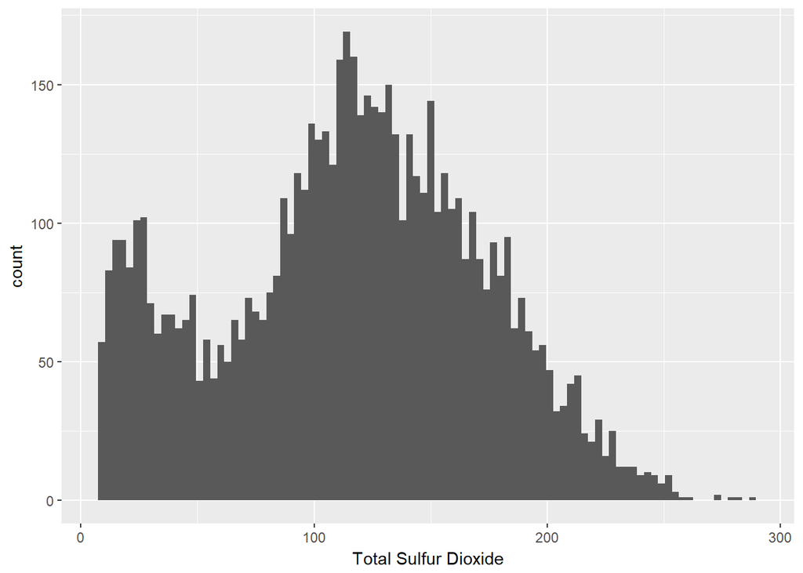

There appears to be some bimodalism with total sulfur dioxide, with a strong peak at 120mg/dm^3 and another weaker peak at 25mg/dm^3.

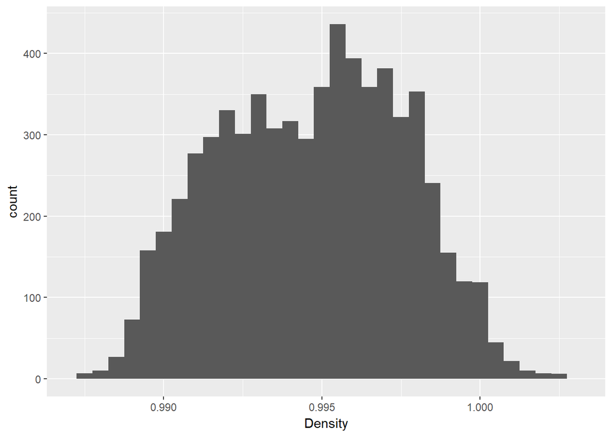

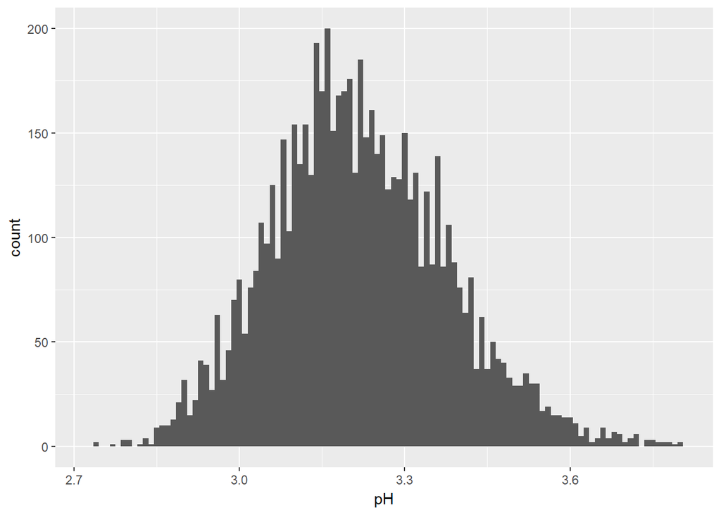

pH exhibits a very normal distribution, whereby median and mean are almost equal at 3.21 and 3.22, respectively.

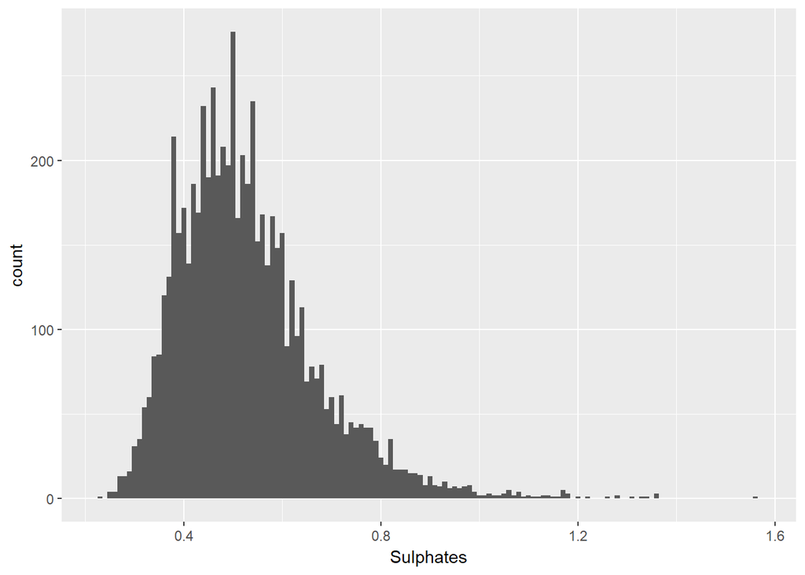

The plot for sulpahtes is slightly right skewed where the mean at 0.53g/dm^3 is slightly greater than the median at 0.51g/dm^3. Most wines, however, are concentrated around 0.51g/dm^3 (median).

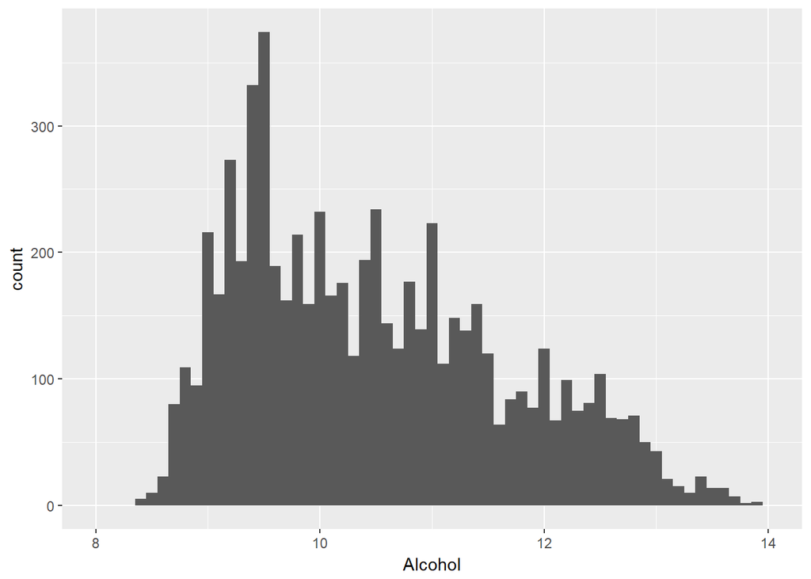

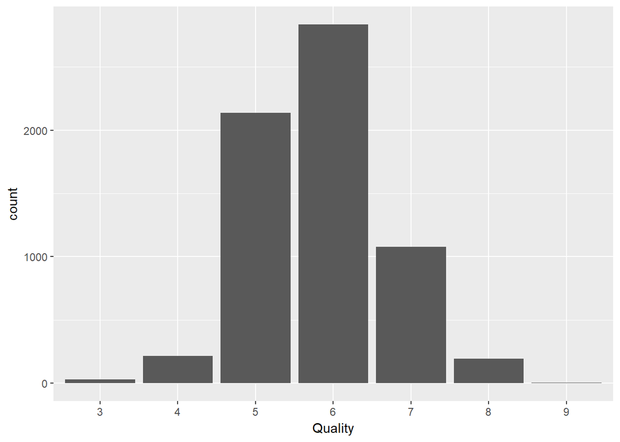

Quality appears to be normally distributed with median equal to 6 and mean equal to 5.8.

I was slightly concerned that there were so many variables that exhibited bimodalism. Below are those list of variables:

1. volatile acidity
2. citric acid
3. residual sugar
4. chlorides
5. free sulfur dioxide
6. total sulfur dioxide
7. density
8. alcohol

However, I wondered whether this was simply because white and red wines differ for these particular properties. Suspecting this was the case, I re-plotted all the graphs above, differentiating between red and white wines:

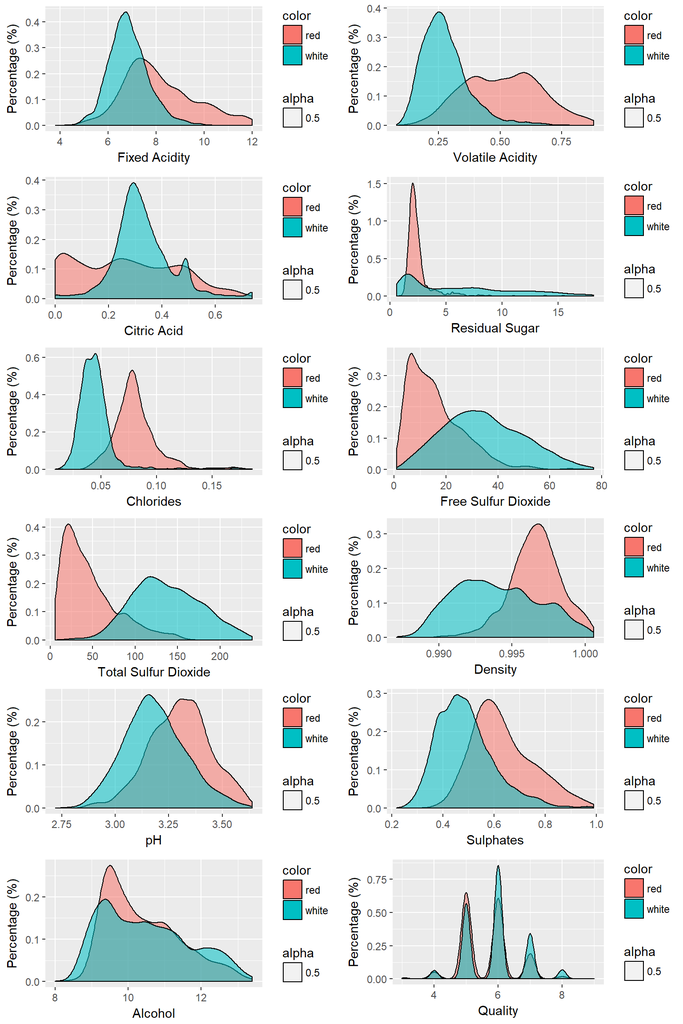

True enough, the plots above show that for almost all properties except fixed acidity, alcohol, and quality, there is a clear distinction between red and white wines, which accounts for the bimodalism in most cases. For example, red wines have a distinctively lower total sulphur dioxide concentration compared to white wines, which is the reason for the bimodalism when the datasets are observed together.

However even for the properties that are seemingly normally distributed, when the red and white wine samples are analyzed separate, properties such as pH are distinctively higher for red wines compared to white wines.

# Univariate Analysis

This dataset contains 6,497 observations (i.e. 6,497 different types of wines - 1,599 red wines and 4,898 white wines). Each observation has 13 variables or properties that describe the characteristics of the wine. Of the 13 properties, 11 are numeric, 1 is an integer, and 1 was a string variable. 3 additional variables were created: quality.ordered, quality.bucket and quality.category. This was to help analyze quality as an ordered variable as well as segregate the wines into categories of low, medium and high quality.

Whilst investigating, I did find some bimodal distributions but it seems the bimodalism was due more in part to differences in properties between red and white wines rather than bimodalism inherent to the variables themselves. Further investigation showed that white and red wines are distinctively different for almost all properties except fixed acidity, alcohol, and quality. This is an important observation as it meant that any future analysis may require red and white wines to be analyzed separately.

Another observation was a noticeable spike in counts at the citric acid level of 0.5 for both red and white wines. A quick search on [Wikipedia](https://en.wikipedia.org/wiki/Acids_in_wine#Citric_acid) showed that wine grapes naturally have an citric acidity of 0.05. Citric acid is often artificially added to wines to boost the wine’s acidity. Therefore the spike at 0.5 may be particular to a certain brand of wine.

Ultimately, this univariate exploration helped me achieve my first goal, which was to identify properties that can be used to differentiate between red and white whites. Some key observations:

1. If you are looking for a sweet wine, you will have more chances of finding what you are looking for if you purchase a white wine
2. White wines tend to be less dense (i.e. lighter) compared to red wines
3. White wines tend to be slightly more acidic than red wines
4. If you are unsure about the alcoholic content of a bottle of wine, it would not matter if it is red or white wine as the distribution of alcholic content is similar for both types of wine.

# Bivariate Plots Section

The best course of action when you do not know where to begin is to plot everything in the hopes that something catches your attention and helps narrow down the variables most relevant for your analysis. However, as higlighted before, because red and white wines are distinctively different for many of these properties, the pairings plot below only compares variables for white wines:

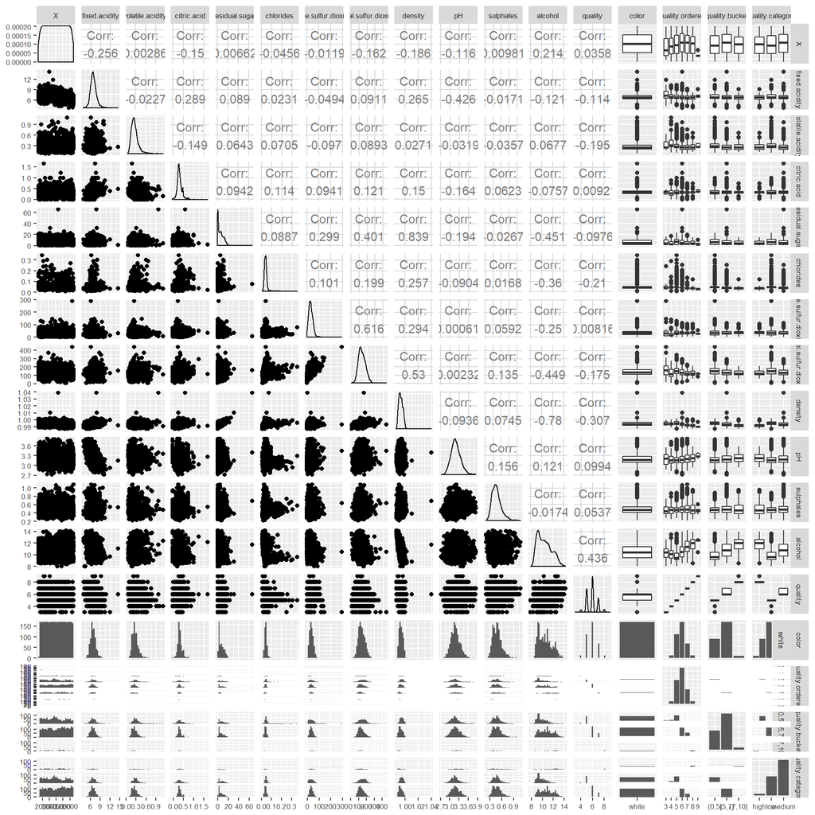

Below are the variables that have a medium or high correlation coefficient assuming the following definitions:

- High correlation: 0.5 to 1.0 or -0.5 to -1.0
- Medium correlation: 0.3 to 0.5 or -0.3 to -0.5
- Low correlation: -0.3 to 0.3

| Variable 1 | Variable 2 | Corr Coefficient | Correlation |
| --- | --- | --- | --- |
| Residual Sugar | Density | 0.839 | High |
| Alcohol | Density | -0.78 | High |
| Total Sulfur Dioxide | Density | 0.53 | High |
| Residual Sugar | Alcohol | -0.451 | Medium |
| Alcohol | Total Sulfur Dioxide | -0.449 | Medium |
| pH | Fixed Acidity | -0.426 | Medium |
| Residual Sugar | Total Sulfur Dioxide | 0.401 | Medium |

I have excluded correlation relationships with the variable X, relationships between free and total sulfur dioxide as these two variables are essentially measuring sulfur dioxide, as well as relationships with quality as these will be addressed separately.

At first glance, it makes sense that density, residual sugar and alcohol have a strong correlation. After all, density is a function of percent alcohol and sugar content. See plots below:

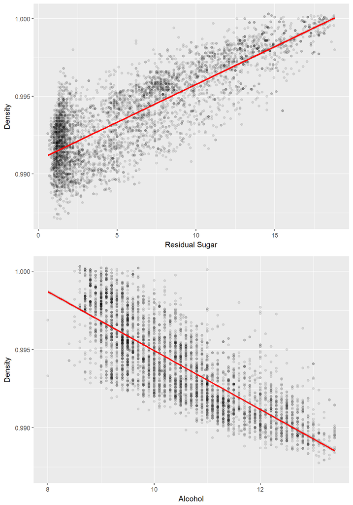

Wine density increases as more sugar is added but decreases as alcholic content increases.

Another expected correlation is the negative relationship between fixed acid and pH. That is, as fixed acidity content levels increase, the pH level decreases or becomes more acidic. See plot below:

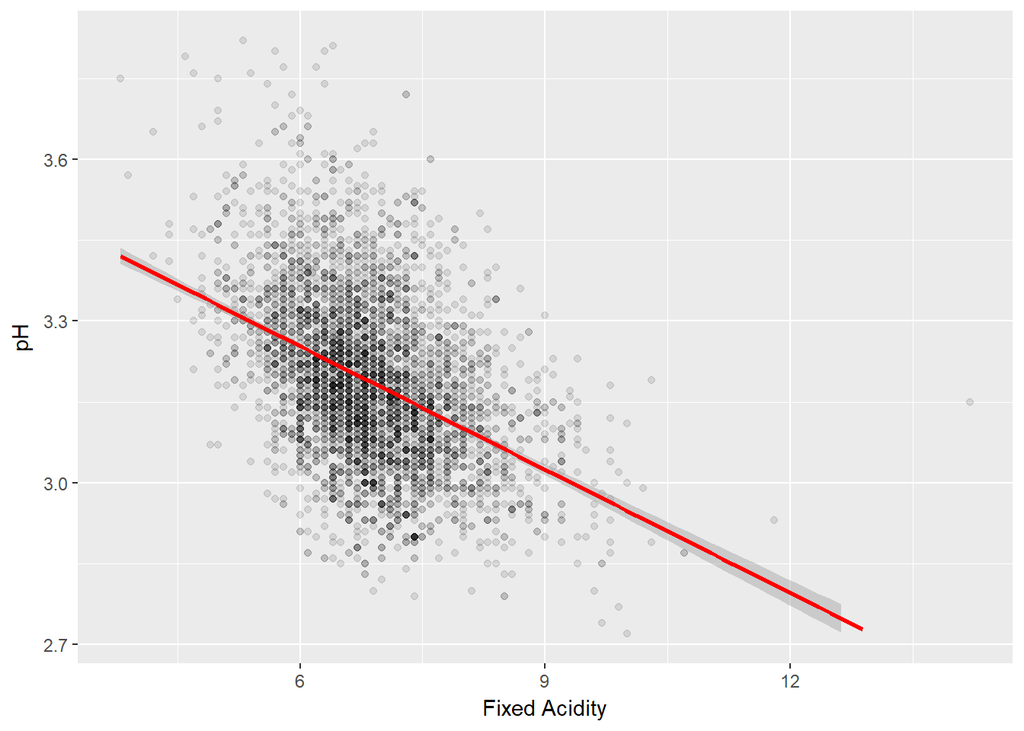

For quality, the following two variables had significant correlation:

- alcohol
- density

**Note**: When analyzing quality, we considered both red and white wines together as there did not appear to be a clear disctinction between the wines in terms of quality.

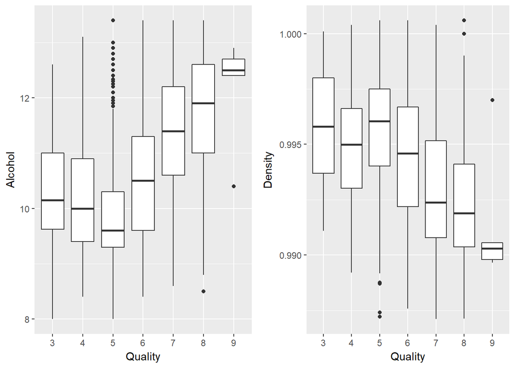

In general, as alcoholic content increases, the quality rating increases. At a alcoholic levels of ~10%, however, the alcoholic content doesn’t seem to influence the quality rating of the wine. As one might expect, because there is a negative relationship between percent alcohol content and density, as density decreases, quality of the wine increases.

But given the strong relationship between alcohol, density and quality, I was surprised not to see a similar relationship between density, residual sugar and quality:

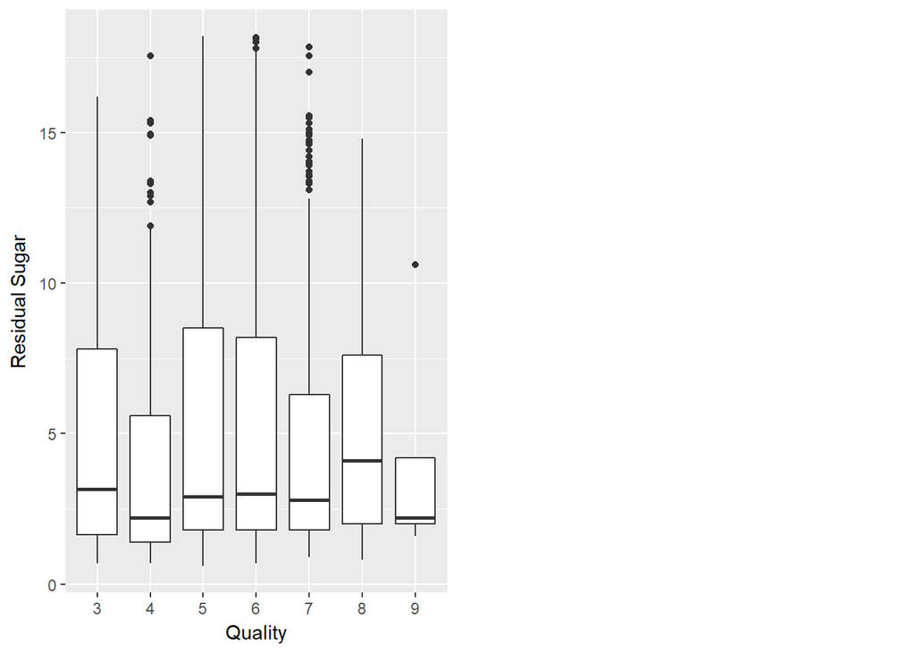

As shown above, a wine sweetness has little correlation to its quality.

# Bivariate Analysis

Some of the relationships observed were expected, and it was reassuring that the data re-confirmed these relationship such as:

1. Postive correlation between density and residual sugar in white wines, which was the strongest relationship
2. Negative correlation between density and alcohol in white wines
3. Negative correlation between fixed acidity and pH in white wines

Other findings were new learnings for me as I did not expect to find a relationship between quality, alcohol and density:

1. Above an alcohol level of 10%, a wine is considered of higher quality as alcoholic content increases
2. Wines that are less dense are considered to be of higher quality
3. Sugar content does not factor significantly into how a wine is rated. At the same sugar level, quality ratings varied between 3 and 7.

One observation I found particularly interesting was that we found correlation between fixed acidity and pH yet did not find a correlation between volatile acidity and pH. I would have assumed that both fixed and volatile acidity would have had a strong negative correlation with pH.

# Multivariate Plots Section

The following plots try to explore if there is a distinction between various wine qualities by looking at the relationship between alcoholic content and density:

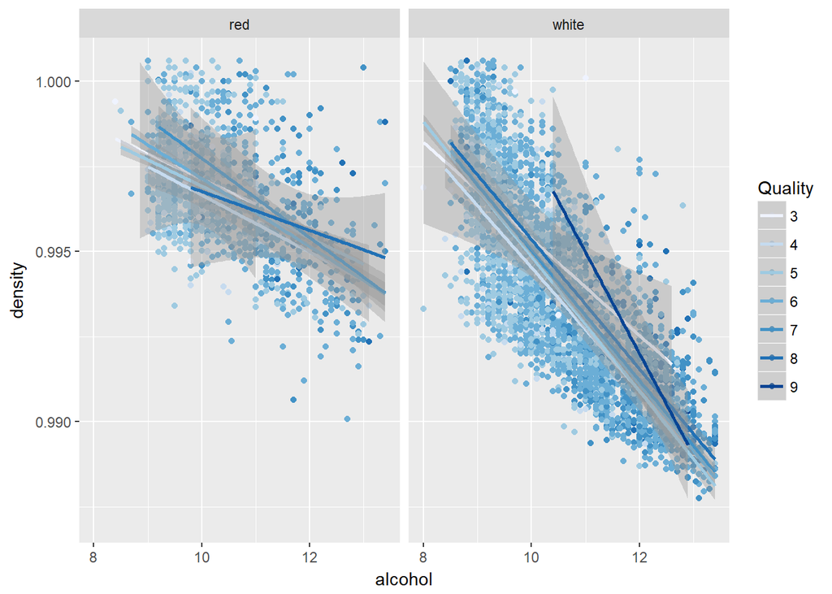

The separation of colors, where higher quality wines are concentrated on the right and lower quality wines are concentrated on the left, a behavior that is observed in both red and white wines, suggests that alcoholic content and density could be a good proxy to estimate wine quality. The following is a linear model of such an estimation:

```
##
## Calls:
## m1: lm(formula = quality ~ alcohol, data = wines)
## m2: lm(formula = quality ~ alcohol + density, data = wines)
## m3: lm(formula = quality ~ alcohol + density + fixed.acidity, data = wines)
##
## ===================================================
##                      m1         m2         m3
## ---------------------------------------------------
##   (Intercept)     2.405***   2.810     -7.550
##                  (0.086)    (4.512)    (5.330)
##   alcohol         0.325***   0.325***   0.339***
##                  (0.008)    (0.011)    (0.012)
##   density                   -0.399     10.096
##                             (4.454)    (5.301)
##   fixed.acidity                        -0.033***
##                                        (0.009)
## ---------------------------------------------------
##   R-squared          0.197      0.197      0.199
##   adj. R-squared     0.197      0.197      0.199
##   sigma              0.782      0.782      0.782
##   F               1597.641    798.702    537.894
##   p                  0.000      0.000      0.000
##   Log-likelihood -7623.404  -7623.400  -7616.772
##   Deviance        3975.734   3975.729   3967.625
##   AIC            15252.809  15254.801  15243.544
##   BIC            15273.146  15281.917  15277.439
##   N               6497       6497       6497
## ===================================================
```

To checked its precision, the model was used to predict quality at 95% confidence for a few test cases:

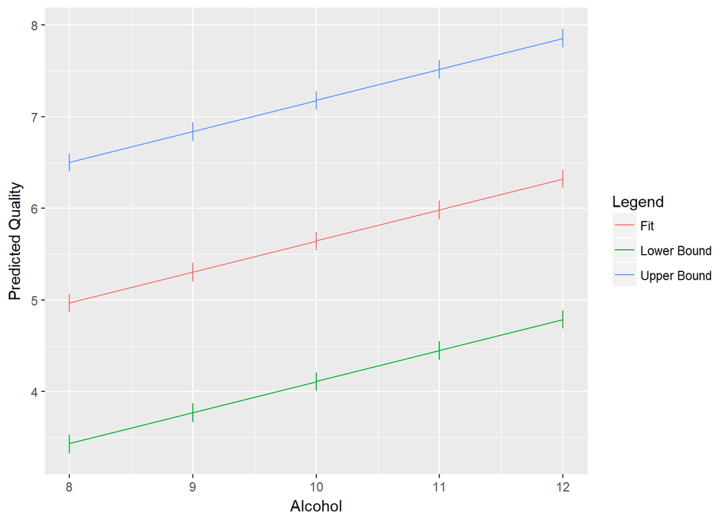

Below is the average difference between the lower/upper bounds of the 95% confidence interval and best-fit prediction:

```
## [1] -1.533452
```

```
## [1] 1.533452
```

From statistics above, it shows that the linear model can predict quality with 95% confidence of +/- 1.53. Meaning that if the model predicts a quality rating of 5.6, you can assume with 95% confidence that the actual quality value is somewhere in between 4.1 and 7.1. Obviously this is not perfect, but if you are simply trying to gauge if the wine is of low, medium or high quality, then it is probably safe to assume that it is of medium quality.

# Multivariate Analysis

The relationship between alcohol, density and quality was reconfirmed by plotting all three variables at once and observing the separation of qualities by color. That is, wines with lower density and higher alcoholic content were rated higher and, inversely, wines with higher density and lower alcoholic content were rated lower. This charateristic was true of both red and white wines.

For this analysis a linear model was created using alcohol content, density, and fixed acidity to predict quality ratings. The r squared value of the predictive model was quite weak at 0.199, which rendered a 95% confidence interval of +/- 1.53 when predicting quality ratings. Nevertheless, if the objective of the model is to simply to differentiate between low, medium and high quality wines, this model should suffice.

# Final Plots and Summary

### Plot One

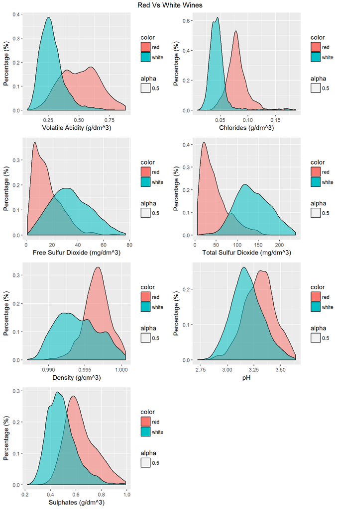

### The Difference Between Red and White Wines

The plots above demonstrate the distinct differences between red and white wines. In general, red whites tend to have higher volatile acidity, cloride content, density, pH levels, and sulphate content. Whilst white wines tend to have higher sulfur dioxide content.

### Plot Two

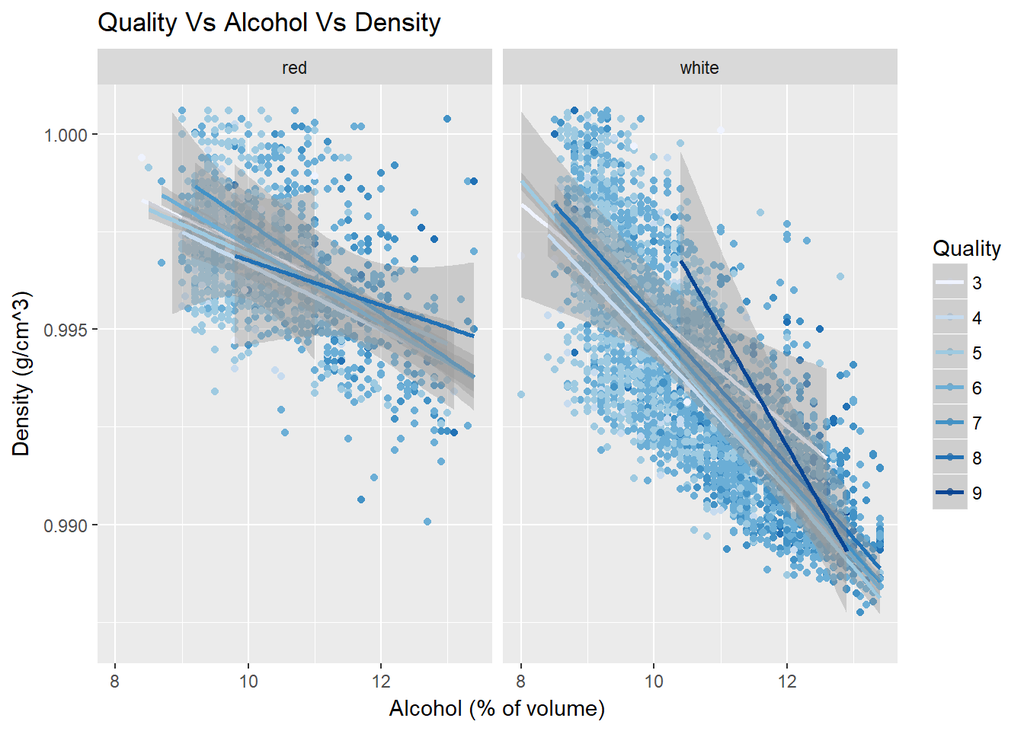

### Quality Vs Alcohol Vs Density

The plot above demonstrates the relationship between quality, alcohol and density whereby quality rating are higher as alcohol content increases and density decreases and, inversely, quality ratings are lower as alcohol content decreases and density increases. This behavior is apparent in both red and white wines.

### Plot Three

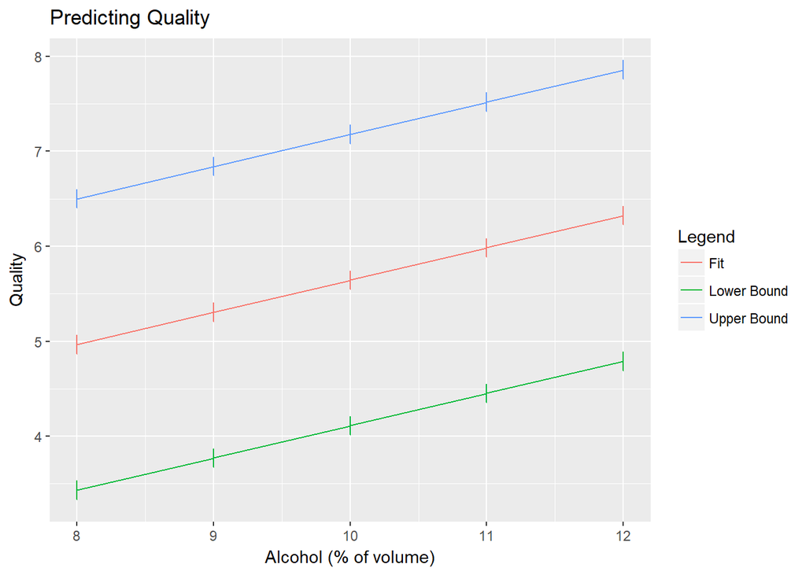

### Accuracy of Linear Model

The linear model above shows predicted quality ratings along with the lower and upper bounds of the 95% confidence interval. The relatively large difference between the lower and upper bounds deomnstrates that the model is not particularly precise in predicting quality based on alcoholic content, density and fixed acidity values. However at the very least, it can be used to distinguish between low, medium and high quality wines.

# Reflection

At the start of this investigation, two goals were established:

1. To find properties that differentiate white and red wines
2. To predict quality rating based on a combination of wine properties

For the first goal, we discovered that pH, sulphates, chlorides, volatile acidity, free/total sulfur dioxide and density can all be used to differentiate between red and white wines.

For the second goal, a linear model was created to estimate quality based on alcoholic content, density and fixed acidity. Though the r squared value of the model was weak at 0.199, the model showed that it could be somewhat useful in differentiating between low, medium and high quality wines.

Given the inability to accurately estimate wine quality ratings, one may conclude that wine ratings are somewhat subjective in nature and are highly dependent on the personal tastes of the testers. Another concern to consider is the limitation of the variables provided. Perhaps other variables like year of production, wine brand, location where grapes were harvested, etc. have more of an influence over quality rating than the variables that we analyzed.

In conclusion, the practical takeaways from this exploration are as such:

1. If you want to appear like an amateur wine connoisseur, check the alcohol content label and test for density before giving an assessment
2. Make sure you provide a vague assessment (i.e. good, average, bad)
3. If your assessment of the quality is way off, just attribute it to preference in taste